# [Siwei Yang 's Data Science](https://wayag.github.io/)

### 3.a) Correlation

Now I 'm wondering whether there is any correlation between each pair of countries in term of overnight. So I caculcated the correlation direct on the data. Let us take a look at the correlation matrix.

```python
newlabel = [t for t in list(df_all.columns) if 'avg_stay' in t]
df_cor = df_all[newlabel]
df_cor.columns = [c[:-9] for c in df_cor.columns]
corr = df_cor.corr()
corr
```

|  | Austria | Belgium | France | Italy | Japan | Netherlands | Sweden | Switzerland | UK | USA |
| --- | --- | --- | --- | --- | --- | --- | --- | --- | --- | --- |
| Austria | 1.000000 | 0.598092 | -0.380081 | 0.100712 | 0.062241 | 0.044285 | 0.299244 | -0.643696 | 0.682802 | 0.517342 |
| Belgium | 0.598092 | 1.000000 | -0.591059 | -0.306068 | -0.273076 | 0.406586 | -0.011389 | -0.727989 | 0.772711 | 0.360978 |
| France | -0.380081 | -0.591059 | 1.000000 | 0.340467 | -0.066385 | -0.583034 | -0.022447 | 0.753844 | -0.793244 | -0.644967 |
| Italy | 0.100712 | -0.306068 | 0.340467 | 1.000000 | 0.713669 | -0.496491 | 0.666431 | 0.000133 | -0.174437 | 0.307461 |
| Japan | 0.062241 | -0.273076 | -0.066385 | 0.713669 | 1.000000 | -0.130041 | 0.577840 | -0.144101 | 0.123823 | 0.652096 |
| Netherlands | 0.044285 | 0.406586 | -0.583034 | -0.496491 | -0.130041 | 1.000000 | -0.300076 | -0.116914 | 0.504038 | 0.148504 |
| Sweden | 0.299244 | -0.011389 | -0.022447 | 0.666431 | 0.577840 | -0.300076 | 1.000000 | -0.281969 | 0.205453 | 0.535944 |
| Switzerland | -0.643696 | -0.727989 | 0.753844 | 0.000133 | -0.144101 | -0.116914 | -0.281969 | 1.000000 | -0.757298 | -0.764586 |
| UK | 0.682802 | 0.772711 | -0.793244 | -0.174437 | 0.123823 | 0.504038 | 0.205453 | -0.757298 | 1.000000 | 0.697935 |
| USA | 0.517342 | 0.360978 | -0.644967 | 0.307461 | 0.652096 | 0.148504 | 0.535944 | -0.764586 | 0.697935 | 1.000000 |

Also a heatmap makes the correlation matrix more demonstrative. In this heatmap, red represents a positive correlation, while blue stands for negative correlation.

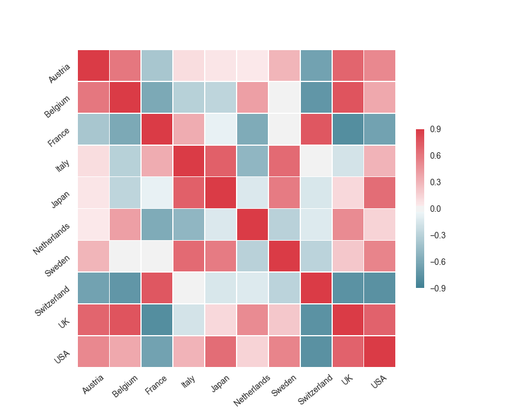

```python
# Set up the matplotlib figure
f, ax = plt.subplots(figsize=(9, 7));

# Generate a custom diverging colormap
cmap = sns.diverging_palette(220, 10, as_cmap=True);

sns.heatmap(corr, cmap=cmap, vmax=.9, square=True, linewidths=.5, cbar_kws={"shrink": .5}, ax=ax)
plt.xticks(rotation=40);
plt.yticks(rotation=40);
```

Whow! it seems that the tourists of some countries have correlated behaviour in term of overnight. For example Uk and Belgium, the corresponding correlation coefficient is 0.772711, meaning that if a English would like have more overnights in Baden-Württemberg, then a Belgian will also want stay longer in this state. It is a very interesting phenomenon. However this seems to be unaccountability. If you look at Japan and Italy, they also have a high correlation 0.713669. But these two countries are almost ten thousands of kilometers apart, and even have two totally different languages and cultures. Reader of this post may ask a question: How do they have such kind of tacit agreement?

Note that correlation is not causation, meaning that just because two things appear to be related to each other doesn’t mean that one causes the other. Furthermore, the correlation what we have could be a so-called [*spurious correlation*](http://www.tylervigen.com/spurious-correlations), which is common problem especially for time series analysis. In exploring relationships between two time series, we should never directly observe this correlation in the first place, indstead we have to remove trend of the data at first. Actually there are already different approaches to deal with this. Now I am going to use a simple and non-parametric method to analyse the relationship between two countries again. It is called first difference. Using first difference we can easily remove the effect of trend. For details about this problem we refer to the [post of Tom Fawcett.](https://svds.com/avoiding-common-mistakes-with-time-series/)

The following code is a simple first difference.

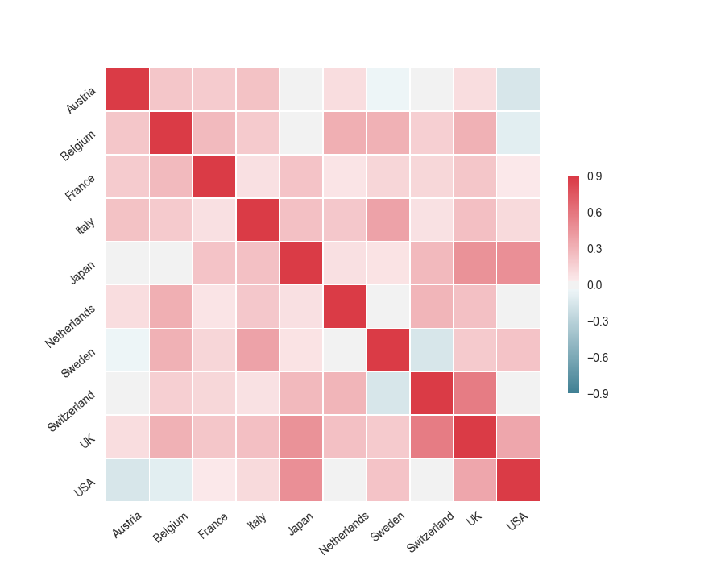

```python
f2, ax2 = plt.subplots(figsize=(9, 7));
df_diff = df_cor.diff();
corr_diff = df_diff.corr()
sns.heatmap(corr_diff, cmap=cmap, vmax=.9, square=True,  linewidths=.5, cbar_kws={"shrink": .5}, ax=ax2)
plt.xticks(rotation=40);
plt.yticks(rotation=40);
```

After differencing, we create the heatmap once again. Now the correlation between each pair of countries becomes much weaker than before, which seems to be more reasonable. *So be carefull, when you want to use correlation for time series.*

### 3.b) Modeling of Time Series

There are standard approaches for modeling of time series. In this article I tried to use the standard techinque to recover some structures from these time series.

Below I will build [autocorrelation function(ACF)](https://en.wikipedia.org/wiki/Autocorrelation) and [partial autocorrelation function(PACF)](https://en.wikipedia.org/wiki/Partial_autocorrelation_function) as well as [QQ-plot](https://en.wikipedia.org/wiki/Q%E2%80%93Q_plot) and probability-plot of our datasets. It turned out that all results are similar , so I think, that it is not necessary to list all counties here. Hence I selected three of them as representative examples. My implemantion was inspired by [this great work.](http://www.blackarbs.com/blog/time-series-analysis-in-python-linear-models-to-garch/11/1/2016)

```python
from pandas import datetime
from matplotlib import pyplot
from pandas.tools.plotting import autocorrelation_plot
import statsmodels.api as sm
import statsmodels.formula.api as smf
import statsmodels.tsa.api as smt
```

```python
import scipy.stats as scs
def tsplot(y, lags=None, figsize=(10, 8), style='bmh'):
    if not isinstance(y, pd.Series):
        y = pd.Series(y)
    with plt.style.context(style):
        fig = plt.figure(figsize=figsize)
        layout = (3, 2)
        ts_ax = plt.subplot2grid(layout, (0, 0), colspan=2)
        acf_ax = plt.subplot2grid(layout, (1, 0))
        pacf_ax = plt.subplot2grid(layout, (1, 1))
        qq_ax = plt.subplot2grid(layout, (2, 0))
        pp_ax = plt.subplot2grid(layout, (2, 1))

        y.plot(ax=ts_ax)
        ts_ax.set_title('Time Series Analysis Plots')
        smt.graphics.plot_acf(y, lags=lags, ax=acf_ax, alpha=0.05)
        smt.graphics.plot_pacf(y, lags=lags, ax=pacf_ax, alpha=0.05)
        sm.qqplot(y, line='s', ax=qq_ax)
        qq_ax.set_title('QQ Plot')
        scs.probplot(y, sparams=(y.mean(), y.std()), plot=pp_ax)

        plt.tight_layout()
    return
```

#### UK

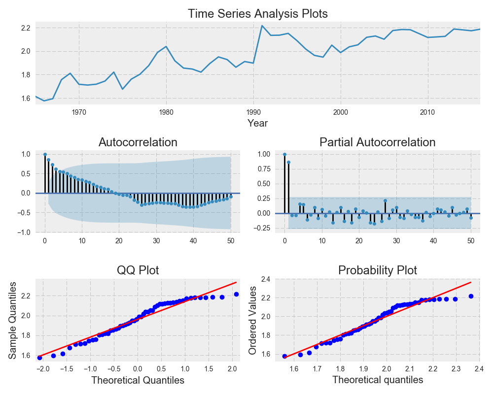

```python
_ = tsplot(df_cor.UK, lags=50);
```

#### Italy

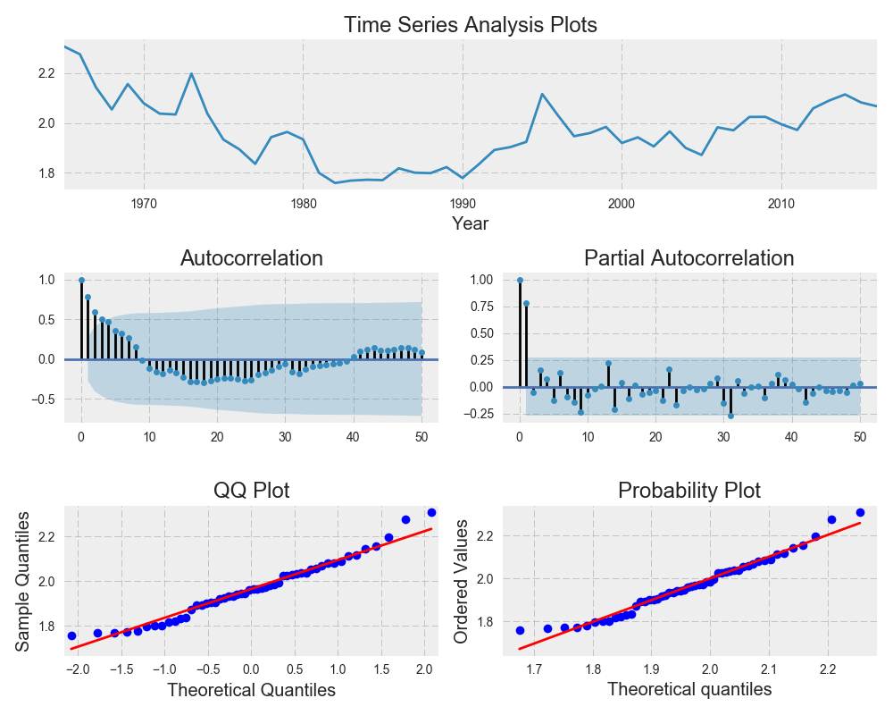

```python
_ = tsplot(df_cor.Italy, lags=50);
```

#### France

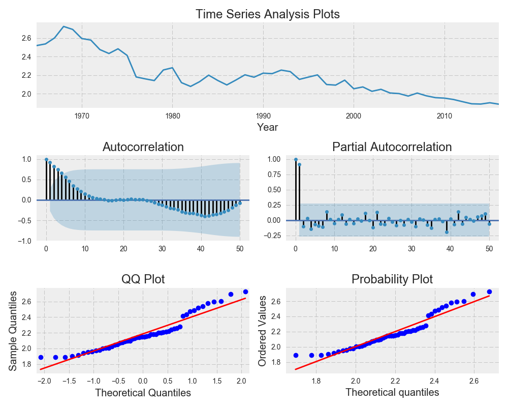

```python
_ = tsplot(df_cor.France, lags=50);
```

Looking at the three examples above, we notice that the partitial autocorrelation(PACF) indicates that an [autoregressive(AR) model](https://en.wikipedia.org/wiki/Autoregressive_model) could be an apropriate model, because it shows a significant cutoff at lag 1. On the other hand, the autocorrelation(ACF) does not exhibit a significant cutoff like the case in PACF, so a pure moving average model may not be a good model. For this reason I first used AR model to describe all countries. Additinally using method `select_order` we can get the best lag order for an AR model.

```python
maxlag = 50
reslist = []
for d in df_cor.columns:
    #print(d)
    mdl = smt.AR(df_cor[d].values).fit(maxlag=maxlag , ic='aic', trend='nc')
    est_order = smt.AR(df_cor[d].values).select_order( maxlag=maxlag, ic='aic', trend='nc')
    reslist.append((d, mdl, est_order))

for i in reslist:
    print('\n country : {}, coef estimate: {:3.4f} {:3.4f} | best lag order = {}'.format(i[0],  i[1].params[0],i[1].params[1], i[2]))
```

```
 country : Austria, coef estimate: 0.7792 0.1964 | best lag order = 1

 country : Belgium, coef estimate: 0.1804 0.1902 | best lag order = 5

 country : France, coef estimate: 0.9559 -0.2886 | best lag order = 29

 country : Italy, coef estimate: 0.9066 -0.1129 | best lag order = 3

 country : Japan, coef estimate: 0.0808 0.0027 | best lag order = 1

 country : Netherlands, coef estimate: 0.9514 0.0505 | best lag order = 14

 country : Sweden, coef estimate: 0.6855 0.0445 | best lag order = 1

 country : Switzerland, coef estimate: 0.6251 0.2873 | best lag order = 7

 country : UK, coef estimate: 0.8668 0.0611 | best lag order = 1

 country : USA, coef estimate: 0.7498 0.2629 | best lag order = 1
```

```python
best_aic = np.inf
best_order = None
best_mdl = None

pq_rng = range(5) # [0,1,2,3,4]
d_rng = range(2) # [0,1]
for i in pq_rng:
    for d in d_rng:
        for j in pq_rng:
            try:
                #print('{} ,{}, {}]'.format(i,d, j))
                tmp_mdl = smt.ARIMA(df_cor.France.values, order=(i,d,j)).fit(method='mle', trend='nc')
                tmp_aic = tmp_mdl.aic
                if tmp_aic < best_aic:
                    best_aic = tmp_aic
                    best_order = (i, d, j)
                    best_mdl = tmp_mdl
            except: continue


print('aic: {:6.5f} | best order: {}'.format(best_aic, best_order))
```

```
aic: -140.08005 | best order: (3, 1, 2)
```

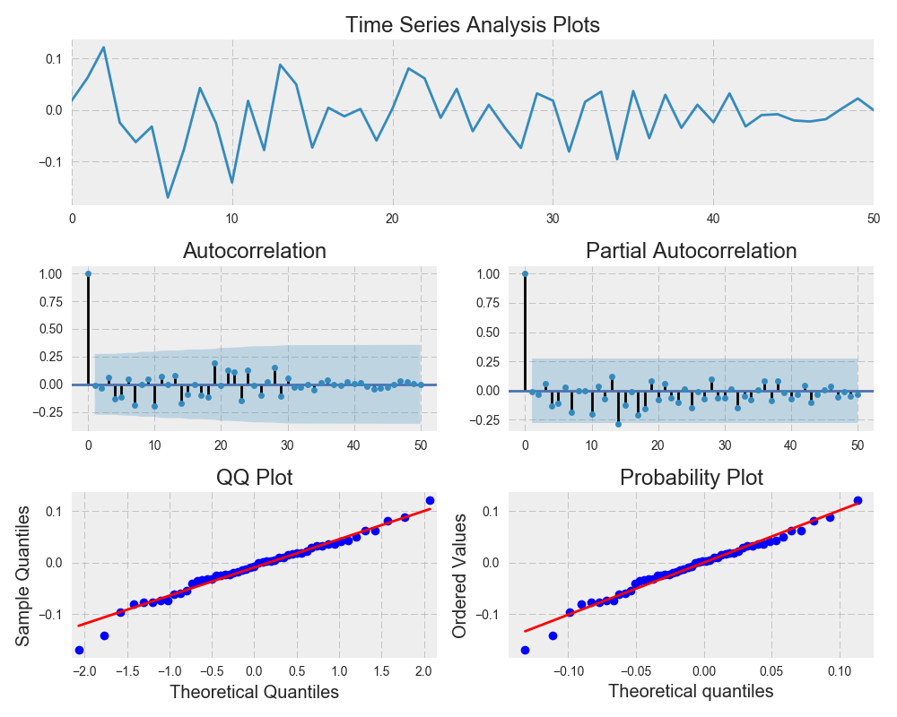

```python
# ARIMA model resid plot

_ = tsplot(best_mdl.resid, lags=50);
```

```python
print(best_mdl.summary())
```

```
                             ARIMA Model Results
==============================================================================
Dep. Variable:                    D.y   No. Observations:                   51
Model:                 ARIMA(3, 1, 2)   Log Likelihood                  76.040
Method:                           mle   S.D. of innovations              0.052
Date:                Wed, 26 Apr 2017   AIC                           -140.080
Time:                        16:57:03   BIC                           -128.489
Sample:                             1   HQIC                          -135.651

==============================================================================
                 coef    std err          z      P>|z|      [0.025      0.975]
------------------------------------------------------------------------------
ar.L1.D.y      1.2439      0.136      9.133      0.000       0.977       1.511
ar.L2.D.y     -1.0997      0.149     -7.358      0.000      -1.393      -0.807
ar.L3.D.y      0.3764      0.131      2.863      0.006       0.119       0.634
ma.L1.D.y     -1.3471      0.081    -16.606      0.000      -1.506      -1.188
ma.L2.D.y      0.9999      0.084     11.928      0.000       0.836       1.164
                                    Roots
=============================================================================
                 Real           Imaginary           Modulus         Frequency
-----------------------------------------------------------------------------
AR.1            0.5002           -1.0643j            1.1759           -0.1801
AR.2            0.5002           +1.0643j            1.1759            0.1801
AR.3            1.9212           -0.0000j            1.9212           -0.0000
MA.1            0.6736           -0.7391j            1.0000           -0.1324
MA.2            0.6736           +0.7391j            1.0000            0.1324
-----------------------------------------------------------------------------
```

```python
from statsmodels.tsa.stattools import ccf
n_steps = 5

f, err95, ci95 = best_mdl.forecast(steps=n_steps) # 95% CI
_, err99, ci99 = best_mdl.forecast(steps=n_steps, alpha=0.01) # 99% CI

idx = pd.date_range(str(df_cor.index[-1]), periods=n_steps, freq='A')
fc_95 = pd.DataFrame(np.column_stack([f, ci95]),
                     index=idx, columns=['forecast', 'lower_ci_95', 'upper_ci_95'])
fc_99 = pd.DataFrame(np.column_stack([ci99]),
                     index=idx, columns=['lower_ci_99', 'upper_ci_99'])
fc_all = fc_95.combine_first(fc_99)
fc_all.head(15)
```

|  | forecast | lower_ci_95 | lower_ci_99 | upper_ci_95 | upper_ci_99 |
| --- | --- | --- | --- | --- | --- |
| 2016-12-31 | 1.874921 | 1.773797 | 1.742022 | 1.976044 | 2.007820 |
| 2017-12-31 | 1.881091 | 1.745259 | 1.702578 | 2.016922 | 2.059603 |
| 2018-12-31 | 1.896663 | 1.744934 | 1.697257 | 2.048393 | 2.096070 |
| 2019-12-31 | 1.904569 | 1.728938 | 1.673750 | 2.080200 | 2.135387 |
| 2020-12-31 | 1.899599 | 1.677575 | 1.607810 | 2.121623 | 2.191388 |

The forecasted value are all about 1.9. We will see, if we have luck with this model. :)